# Final Project - Practical Machine Learning

Domenico Ierullo

2015-05-18

# Abstract

Using special devices for activity tracking and fitness monitoring, it’s possible collect a large amount of data about Human Activity Recognition (HAR).

The aim of this project is to analyze a set of data obtained from http://groupware.les.inf.puc-rio.br/har; these datasets represent readings of accelerometers places on the belt, forearm, arm, and dumbell of 6 participants.

They were asked to perform barbell lifts Correctly and incorrectly in 5 different ways.

The datasets was used to predict how well they were doing the exercise in terms of the classification in the data.

### Libraries

Load libraries

```r
library(caret)
```

```r
library(corrplot)
library(randomForest)
```

Set work directory and seed

```r
setwd("C:\\Users\\ierul_000\\Downloads\\")
set.seed(5423)
```

### Load and clean trainig dataset

Load training dataset and replace the missing or null values with the symbol NA:

```r
training <- read.csv("C:\\Users\\ierul_000\\Downloads\\pml-training.csv",na.strings= c("NA",""," ","#DIV/0!"))
```

Remove the first seven columns (identifiers) and clean the data by deleting columns with NA values:

```r
training   <-training[,-c(1:7)]

training <- training[,which(apply(training, 2, function(x) {sum(is.na(x))}) == 0)]
```

### Create model

The dataset was split in a 60:40 ratio in order to use data for training, cross validation and testing

```r
train <- createDataPartition(y = training$classe, p = 0.6, list = FALSE)
xtrain <- training[train, ]
xtest <- training[-train, ]
```

For this classification problem, random forest model was selected, after observing the correlation matrix to know variables relationship with each other

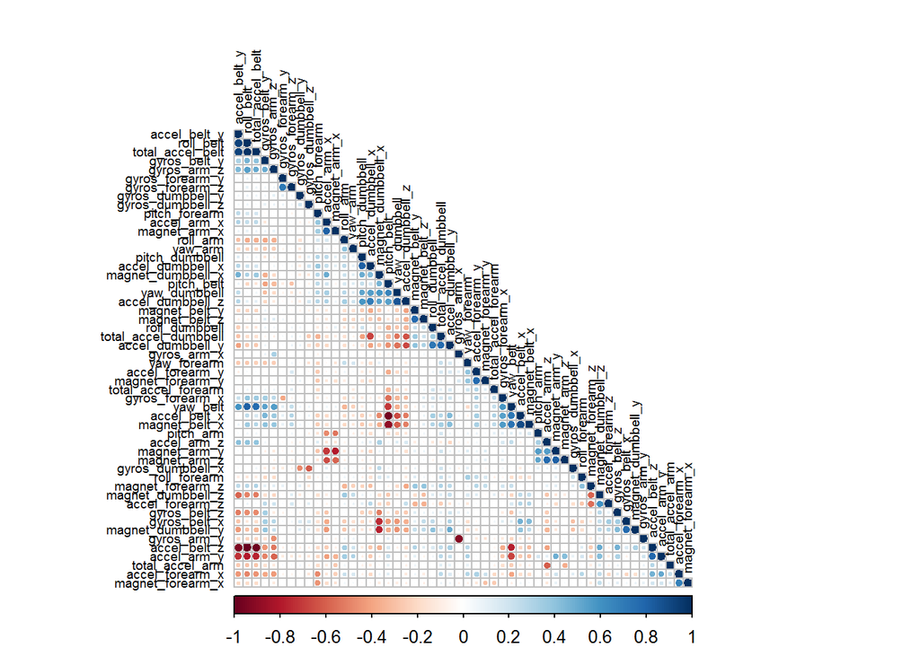

```r
correlationMatrix <- cor(xtrain[, -length(xtrain)])
corrplot(correlationMatrix, order = "hclust", addrect = 3, method = "circle" , type = "lower", tl.cex = 0.6 ,  tl.col = rgb(0, 0, 0))
```

After this analisys we build the model,

```r
model <- randomForest(classe ~ ., data = xtrain)
model
```

```
##
## Call:
##  randomForest(formula = classe ~ ., data = xtrain)
##                Type of random forest: classification
##                      Number of trees: 500
## No. of variables tried at each split: 7
##
##         OOB estimate of  error rate: 0.66%
## Confusion matrix:
##      A    B    C    D    E class.error
## A 3344    3    0    0    1 0.001194743
## B   11 2264    3    1    0 0.006581834
## C    0   16 2034    4    0 0.009737098
## D    0    0   25 1903    2 0.013989637
## E    0    0    3    9 2153 0.005542725
```

The model summary show OOB estimate of error rate is 0.66%, acceptable rate.

Using the 40% remaining data, make a crossvalidation for the model and show the confusion matrix to know prediction accuracy

```r
CrossVal <- predict(model, xtest)
confusionMatrix(xtest$classe, CrossVal)
```

```
## Confusion Matrix and Statistics
##
##           Reference
## Prediction    A    B    C    D    E
##          A 2231    1    0    0    0
##          B   15 1498    5    0    0
##          C    0    4 1364    0    0
##          D    0    0   10 1274    2
##          E    0    0    3    3 1436
##
## Overall Statistics
##
##                Accuracy : 0.9945
##                  95% CI : (0.9926, 0.996)
##     No Information Rate : 0.2863
##     P-Value [Acc > NIR] : < 2.2e-16
##
##                   Kappa : 0.9931
##  Mcnemar's Test P-Value : NA
##
## Statistics by Class:
##
##                      Class: A Class: B Class: C Class: D Class: E
## Sensitivity            0.9933   0.9967   0.9870   0.9977   0.9986
## Specificity            0.9998   0.9968   0.9994   0.9982   0.9991
## Pos Pred Value         0.9996   0.9868   0.9971   0.9907   0.9958
## Neg Pred Value         0.9973   0.9992   0.9972   0.9995   0.9997
## Prevalence             0.2863   0.1916   0.1761   0.1628   0.1833
## Detection Rate         0.2843   0.1909   0.1738   0.1624   0.1830
## Detection Prevalence   0.2845   0.1935   0.1744   0.1639   0.1838
## Balanced Accuracy      0.9966   0.9968   0.9932   0.9979   0.9988
```

The accuracy result was 99,45% and confirm random forest model is good for this classification problem.

### Make predicition

Load testing dataset and replace the missing or null values with the symbol NA:

```r
testing <- read.csv("C:\\Users\\ierul_000\\Downloads\\pml-testing.csv",na.strings= c("NA",""," ","#DIV/0!"))
testing    <-testing[,-c(1:7)]
datatest <- testing[,which(apply(testing, 2, function(x) {sum(is.na(x))}) == 0)]
```

Predict dataset classes

```r
prediction <- predict(model, datatest)
prediction
```

```
##  1  2  3  4  5  6  7  8  9 10 11 12 13 14 15 16 17 18 19 20
##  B  A  B  A  A  E  D  B  A  A  B  C  B  A  E  E  A  B  B  B
## Levels: A B C D E
```